# Analiza skupień dla państw UE pod kątem konkurencyjności gospodarek

Jakub Górowski

30.10.2019

# Wstęp

Obecny świat w znacznym stopniu opiera się na technologii. Rozwiązania chmurowe i stale rosnaca moc obliczeniowa którą możemy zabać ze spobą gdziekolwiek ułatwiają nasze życie. Tak naprawdę jednak stoimy na progu czwartej rewolucji przemysłowej. Coraz doskonalsza sztuczna inteligencja, technologie oparte o blockchain, czy też Internet rzeczy zmienią nasze otoczenie w sposób którego nie jesteśmy sobie w stanie wyobrazić. Naszą rzeczywistość kształtują często pomysły innowatorów i wizjonerów. Choć obarczone dużym ryzykiem, to jednak dzięki zaufaniu inwestorów i zainteresowaniu społeczeństw mogą odnosić sukcesy. Obecnie za kolebkę takich rozwiązań uważa się Krzemową Dolinę. Co jednak na to wpłynęło? Z pewnością nie były to same regulacje prawne, czy też idealny system edukacji. Autor niniejszego opracowania wybrał 14 różnych czynników które, jego zdaniem, wpływają na konkurencyjność państw w przyciąganiu twórców innowacyjnych rozwiązań i inwestorów zainteresowanych ich realizacją. Celem pracy jest, z pomocą metod analizy skupień, wybrać takie państwa, w których panują najlepsze warunki do tworzenia i wdrażania nowoczesnych technologii oraz innowacyjnych pomysłów.

# Rozpatrywane zmienne

W projekcie wzięto pod uwagę zmienne dotyczące różnych aspektów gospodarki - od infrastruktury poprzez system edukacji, aż po stopień biurokratyzacji. Autorzy GCI, których bazą posłużono się w niniejszym projekcie przeprowadzili ankietę wśród osób na stanowiskach kierowniczych pochodzących z różnych krajów. Oceniano w niej na 7 stopniowej skali Likerta poszczególne zagadnienia składające się na 12 filarów. Ponadto autorzy raportu wykorzystali również zmienne liczbowe ze skali ilorazowej, takie jak liczba zgłoszonych patentów, czy też produkt krajowy brutto. Część ze zmiennych to udział procentowy wyrażony w punktach procentowych.

### ZaufaniePolicja

Respondentom zadano pytanie: *W Twoim kraju, w jakim zakresie można polegać na działaniach policji w zakresie chronienia prawa i utrzymywania porządku? [1 oznacza wcale; 7 znaczy w pełni]*. Sprawnie działająca policja wpływa na poczucie stabilności i bezpieczeństwa. Zwłaszcza działania wyspecjalizowanych służb pomagają chronić wolną i sprawiedliwą konkurencję.

### ZaufaniePolitycy

Respondentom zadano pytanie: *Jak oceniasz etyczne standardy polityków w Twoim kraju? [1 oznacza bardzo niskie; 7 znaczy bardzo wysokie]*. Ograniczenia i wymogi narzucane przez regulatorów mogą przyczynić się do zmiany kondycji niejednego biznesu. Z tego powodu warto wiedzieć, czy można zaufać obietnicom i deklaracjom składanym przez polityków.

### OWI

Respondentom zadano pytanie: *W jakim stopniu chroniona jest własność intelektualna w Twoim kraju? [1 oznacza wcale; 7 znaczy w pełni]*. Poziom ochrony własności intelektualnej ma znaczenie szczególnie dla firm z branży technologicznej. To właśnie wiedza zapewnia im przewagę na rynku.

### DlugoscZycia

Zmienna ta pochodzi z bazy danych Banku Światowego (konkretnie *World Development Indicators*). Opisuje ona prognozowaną długość życia, dla osoby urodzonej w 2017r., jeżeli nie zmienią się wzorce kulturowe panujące w społeczeństwie. Wyrażana jest w latach. Obrazuje ona poziom opieki medycznej oraz politykę państwa wobec seniorów. Z tego powodu znalazła się w grupie rozpatrywanych zmiennych - dla przedsiębiorstwa może mieć znaczenie, ile lat będą żyć jego przyszli pracownicy, a także jak funkcjonuje ogólnodostępna opieka zdrowotna.

### SysEdukacji

Respondentom zadano pytanie: *Jak bardzo system edukacji w Twoim kraju jest dostosowany do potrzeb aktualnego rynku pracy? [1 oznacza wcale; 7 znaczy w pełni]*. Często poruszany temat w dyskusjach nad systemem edukacji, to zbyt duży nacisk na naukę teorii. Niektórzy uważają, że studenci określonych kierunków są po ich ukończeniu *skazani* na bezrobocie lub pracę w innym zawodzie. Ponadto w wypadku zakończenia edukacji na etapie liceum czy technikum, szanse na zatrudnienie są również niskie. Z drugiej strony rynek pracy nieustannie ewoluuje, a jego wymagania czasami są nieadekwatne do rzeczywistych oczekiwań pracodawców. Zmienna ta obrazuje jak, według pracodawców, system edukacji danego kraju radzi sobie w tej trudnej kwestii.

### CałkowitePodatki

Zmienna ta przedstawia całkowitą stawkę opodatkowania (wyrażaną w procentach) nałożoną na przedsiębiorstwo w drugim roku jego działalności. W jej skład wchodzą CIT, jaki i wszelkie inne podatki lub skłądki płacone przez pracodawcę na rzecz pracownika. Dla każdego przedsiębiorstwa korzystna jest jak najniższa wartość tej stawki, stąd działania takie jak *optymalizacja podatkowa* zmierzajace do jej redukcji.

### KobietyPracujące

Zmienna ta przedstawia stosunek procentowego udziału kobiet w wieku 15-64 lat aktywnych zawodowo do analogicznej grupy mężczyzn. Im większy ten iloraz, tym więcej kobiet na rynku pracy, a zatem jest on większy. W takiej sytuacji pracodawca powinien mieć większą łatwość w poszukiwaniu pracowników.

### UżytkownicyInternetu

Zmienna ta przedstawia procentowy udział osób korzystajacych z Internetu wśród populacji danego kraju. Za osobę używającą internetu traktowana jest osoba która w ciągu ostatnich 3 miesięcy chociaż raz używała internetu w dowolnym celu i z dowolnego źródła. Choć wydawać by się mogło, że obecnie Internet jest powszechny na terenie UE, to jednak statystyki opisowe tej zmiennej zdają się świadczyć o czymś zupełnie innym. W Uni Europejskiej istnieje kraj, w którym Internetu używa niecałe 60% populacji. Ponadto średnia wynosi około 80% i jest bliska medianie, co świadczy o braku szczególnie skrajnych wartości, które miałyby wpłynąć na średnią. Dla przedsiębiorców powszechność Internetu zwiększa zarówno możliwości promocji i kanały sprzedaży, jak i świadczy o większym *obyciu z technologią* danego społeczeństwa, a zatem również - przyszłych pracowników. Ponadto lepiej jest testować i wdrażać nowoczesne rozwiązania wśród społeczeństwa które będzie z nich korzystać.

### Prędkość Internetu

W świecie w którym znaczna część przedsiębiorstw wykorzystuje technologie chmurowe, a spotkania biznesowe realizowane są w formie internetowych *call’i* bardzo ważna staje się prędkość naszego połączenia z siecią. Im jest większa, tym bardziej możemy polegać na wszystkich usługach korzystających z Internetu. Zmienna PredkoscInternetu przedstawia właśnie tę prędkość - wyrażoną w kb/s na użytkownika Interentu w danym kraju. Na terenie UE zauważyć można jeden szczególny outlier - jest to Luksemburg. Możeon szczycić się bardzo wysoką średnią prędkością, niemal 80 razy większą niż mediana UE.

### Patenty

Zmienna ta reprezentuje liczbę zgłoszonych patentów przypadającą na milion mieszkańców. Świadczy ona o przedsiębiorczości i kreatywności społeczeństwa. Weryfikuje poniekąd także edukację wyższą - to czy uczy ona jedynie teorii, czy także zachęca do kreatywnego myślenia. Im więcej patentów zgłasza dany kraj, tym większa szansa na pozyskanie twórczych pracowników, którzy przyczynią się do sukcesu firmy. Warto nadmienić, że zmienna Patenty uwzględnia narodowość osoby zgłaszającej patent, a nie miejsce jego zgłoszenia. Z tego powodu jest bardziej miarodajna, ponieważ ukazuje również działalność osób pracujących za granicą w międzynarodowych korporacjach.

### Procedury Biznes

Zmienna ta przedstawia liczbę procedur związaną z zakładaniem własnego biznesu. Ich nadmiar może zniechęcić potencjalnych przedsiębiorców. Świadczy również o ogólnej biurokratyzacji państwa.

### Dni Biznes

Zmienna ta przedstawia liczbę dni roboczych, jaka jest wymagana aby rozpocząć działalność gospodarczą. Przeciągajace się w nieskończoność oczekiwanie, podobnie jak nadmiar procedur, wpływa negatywnie na chęć założenia własnego biznesu.

### Zmiana inflacji

Roczna zmiana inflacji przekazuje nam istotne informacje o stanie gospodarki danego kraju. Jej wysoka wartość oznacza m. in. niezrównoważony budżet państwa, czy też zbyt dużą ilość pieniędzy w obiegu. Z kolei ujemne wartości okreslane są jako deflacja - świadczą o stagnacji wzrostu gospodarczego. Uważa się, że niska wartośc inflacji (rzędu 2% w skali roku) jest zjawiskiem pozytywnym.

### Fundusze venture capital

Respondentom zadano pytanie: *Jak łatwo start-up’y z innowacyjnymi, lecz ryzykownymi projektami są w stanie otrzymać brakujący kapitał? [1 oznacza ekstremalnie trudno; 7 znaczy bardzo łątwo]*. Często bardzo dochodowe przedsięwzięcia zaczynają się od ryzykownych pomysłów, które jednak według ich twórców - mogą zrewolucjonizować świat. Zmienna ta oznacza jak w danym kraju wspierani są innowatorzy - czy mogą liczyć na dofinansowanie, jak wiele związane jest z tym biurokracji. Obecnie niektóre firmy w ramach swoich struktur wyodrębiają jednostki o charakterze start-up’owym - dostępność obcego kapitału może być dla nich okazją do realizacji pomysłu, bez ryzykowania majatkiem przedsiębiorstwa.

# Ocena danych

## Zmienność

Aby otrzymać poprawne wnioski w analizie skupień, należy sprawdzić czy zmienne nie są quasi-stałe. Muszą one charakteryzować się zmiennością nie mniejszą niż 10%

```
##  [1]  TRUE  TRUE  TRUE FALSE  TRUE  TRUE FALSE  TRUE  TRUE  TRUE  TRUE
## [12]  TRUE  TRUE  TRUE
```

Okazuje się, że wśród rozpatrywanych zmiennych DlugoscZycia oraz KobietyPracujace charakteryzują się bardzo niskim poziomem współczynnika zmienności. Wynika z tego, że w Uni Europejskiej zarówno oczekiwana długość życia, jak i stosunek pracujących kobiet do męszczyzn jest na podobnym poziomie. Szczególnie quasi-stałość pierwszej zmiennej jest interesująca - pokazuje, że pomimo różnic w zamożności pomiędzy poszczególnymi krajami członkowskimi UE, ich obywatele dożywają obecnie podobnego wieku. Natomiast obecność w tej grupie zmiennej przedstawiającej iloraz odsetków osób obojga płci aktywnych zawodowo nie powinna dziwić - zarówno we wschodniej jak i zachodniej Europie z emancypacja kobiet była powszechna w pierwszej połowie XX w., a obecnie funkcjonujące wzorce kulturowe dotyczące aktywności zawodowej kobiet są identyczne na jej terytorium. Kobiety są traktowane na rynku pracy na równi z mężczyznami, a wszelkie odstępstwa od tej zasady spotykają się z krytyką społeczeństwa. Z tych powodów odsetek kobiet aktywnych zawodowo jest porównywlny w całej UE, a zatem posiada niewielki współczynnik zmienności.  
Obydwie zmienne zostają usunięte ze zbioru dancyh.

## Korelacja

Ropatrywane zmienne nie mogą być nadmiernie skorelowane ze sobą nawzajem, ponieważ zaburzyć to może wyniki klasyfikacji. Powinny być jednak również minimalnie skorelowane ze sobą nawzajem.

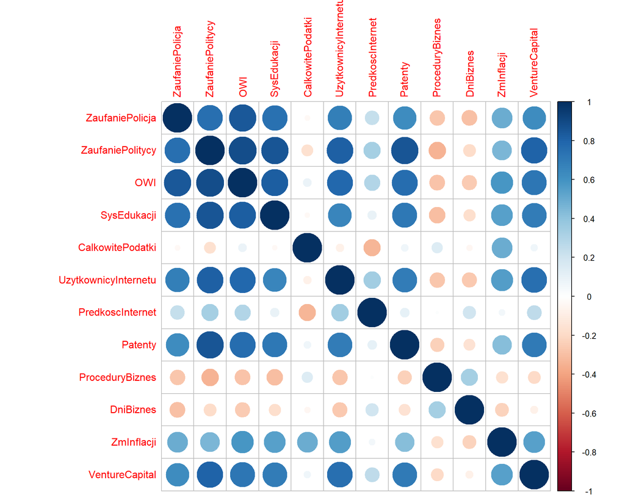

```
##                      ZaufaniePolicja ZaufaniePolitycy   OWI SysEdukacji
## ZaufaniePolicja                 1.00             0.75  0.85        0.74
## ZaufaniePolitycy                0.75             1.00  0.89        0.85
## OWI                             0.85             0.89  1.00        0.83
## SysEdukacji                     0.74             0.85  0.83        1.00
## CalkowitePodatki               -0.03            -0.16  0.08       -0.03
## UzytkownicyInternetu            0.69             0.81  0.78        0.65
## PredkoscInternet                0.24             0.33  0.30        0.10
## Patenty                         0.63             0.86  0.77        0.72
## ProceduryBiznes                -0.27            -0.35 -0.28       -0.31
## DniBiznes                      -0.29            -0.19 -0.26       -0.17
## ZmInflacji                      0.49             0.45  0.58        0.54
## VentureCapital                  0.63             0.80  0.72        0.70
##                      CalkowitePodatki UzytkownicyInternetu
## ZaufaniePolicja                 -0.03                 0.69
## ZaufaniePolitycy                -0.16                 0.81
## OWI                              0.08                 0.78
## SysEdukacji                     -0.03                 0.65
## CalkowitePodatki                 1.00                -0.08
## UzytkownicyInternetu            -0.08                 1.00
## PredkoscInternet                -0.34                 0.35
## Patenty                          0.07                 0.69
## ProceduryBiznes                  0.14                -0.28
## DniBiznes                       -0.04                -0.26
## ZmInflacji                       0.49                 0.55
## VentureCapital                   0.06                 0.76
##                      PredkoscInternet Patenty ProceduryBiznes DniBiznes
## ZaufaniePolicja                  0.24    0.63           -0.27     -0.29
## ZaufaniePolitycy                 0.33    0.86           -0.35     -0.19
## OWI                              0.30    0.77           -0.28     -0.26
## SysEdukacji                      0.10    0.72           -0.31     -0.17
## CalkowitePodatki                -0.34    0.07            0.14     -0.04
## UzytkownicyInternetu             0.35    0.69           -0.28     -0.26
## PredkoscInternet                 1.00    0.11            0.01      0.19
## Patenty                          0.11    1.00           -0.23     -0.16
## ProceduryBiznes                  0.01   -0.23            1.00      0.34
## DniBiznes                        0.19   -0.16            0.34      1.00
## ZmInflacji                       0.05    0.43           -0.17     -0.22
## VentureCapital                   0.26    0.70           -0.19     -0.07
##                      ZmInflacji VentureCapital
## ZaufaniePolicja            0.49           0.63
## ZaufaniePolitycy           0.45           0.80
## OWI                        0.58           0.72
## SysEdukacji                0.54           0.70
## CalkowitePodatki           0.49           0.06
## UzytkownicyInternetu       0.55           0.76
## PredkoscInternet           0.05           0.26
## Patenty                    0.43           0.70
## ProceduryBiznes           -0.17          -0.19
## DniBiznes                 -0.22          -0.07
## ZmInflacji                 1.00           0.55
## VentureCapital             0.55           1.00
```

Korelogram sugerować może nadmierną korelację między zmiennymi. Po dokładnym sprawdzeniu jednak, dla żadnej pary zmiennych jej współczynnik korelacji nie przekracza 0,9. Oznacza to, że wyniki nie będą zaburzone. Z uwagi na bardzo małą korelację zmiennej CalkowitePodatki zadecydowano o usunięciu jej ze zbioru.

# Normalizacja i outliery

Obecność wartości odstających również zaburzyć może wyniki klasyfikacji. Najprostszą metodą na sprawdzenie ich występowania jest graficzne interpretacja wykresów pudełkowych po normalizacji zmiennych. W tym celu wykorzystano funkcję data.Normalization (ustawiona metoda normalizacji to n1, czyli standaryzacja). Ponadto normalizacja pozwala wprowadzić porównywalność - bez niej część wartości przyjmowałaby skalę od 1 do 7, a inne od dziesiątek do tysięcy. Wówczas wpływ tych zmiennych jest różny, co zaburza poprawne grupowanie.

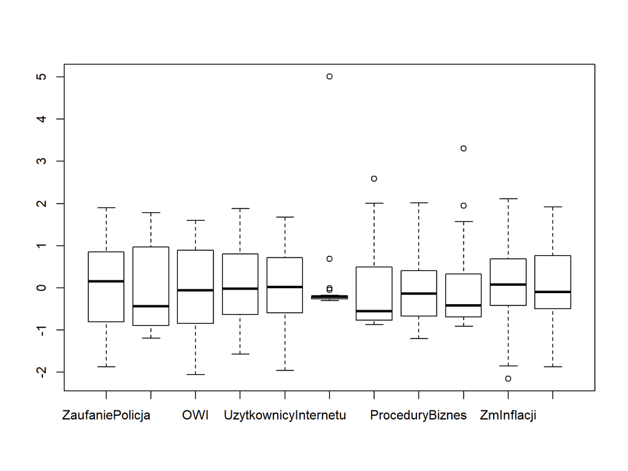

Na wykresach pudełkowych zauważyć można obecność outlierów pod kątem zmiennych nr 6, 7, 9, 10 (PredkoscInternet, Patenty, DniBiznes oraz ZmInflacji). Postanowiono również sprawdzić obecność outlierów za pomocą testu Grubbsa. W tym celu autor opracował kod, weryfikujący liczbę outlierów wśród poszczególnych zmiennych, aby móc lepiej ocenić, czy konkretne obserwacje są odstające na wielu płaszczyznach.

```r
outliers<-matrix(FALSE,nrow=28,ncol=11) #tworzona jest macierz, gdzie dla każdej obserwacji zapisane zostanie czy i dla której zmiennej jest outlierem
outliersWzm<-c() #wektor w którym zostanie zsumowana liczba outlierów dla każdej zmiennej
outliersWobs<-c() # wektor w którym zostanie zapisane ile razy dana obserwacja była outlierem
rownames(outliers)<-rownames(DaneC)


for(i in 1:11){ #każdy obiekt pętli wykonujemy dla konkretnej zmiennej
  Dane<-DaneC
  test<-grubbs.test(Dane[,i]) #wykonywany jest test Grubbsa
  liczbaoutlierow=0 #liczba outlierów dla i-tej zmiennej ustawiana jest na 0
  while(test$p.value<0.05){ #pętla będzie się wykonywać do póki test Grubbsa będzie wykrywać outliery

    tempoutlier<-as.numeric(strsplit(test$alternative," ")[[1]][3]) #sprawdzana w teście obserwacja zostaje "wyłuskana"
    liczbaoutlierow=liczbaoutlierow+1  #następuje zwiększenie liczby outlierów
    outliers[match(tempoutlier,DaneC[,i]),i] = TRUE #dana obserwacja zostaje oznaczona jako outlier w macierzy outliers
    Dane<-subset(Dane, Dane[,i]!=tempoutlier) #następnie zostaje ona usunięta ze zbioru
    test<-grubbs.test(Dane[,i]) # ponownie wykonywany jest test Grubbsa, aby sprawdzić czy nie wystepuje więcej outlierów


  }

  outliersWzm[i]<-liczbaoutlierow #liczba outlierów zostaje zapisana

}

for (i in 1:28){ #podwójna pętla for iteruje po macierzy outliers, aby sprawdzić ile razy dana obseracja była outlierem
  liczbaoutlierow = 0
  for(j in 1:11){
    if(outliers[i,j]==TRUE)
      {liczbaoutlierow <- liczbaoutlierow + 1}
  }
  outliersWobs[i] = liczbaoutlierow
}
nazwy<-rownames(DaneC)
names(outliersWobs)<-nazwy
nazwy<-colnames(DaneC)
names(outliersWzm)<-nazwy

outliersWobs
```

```
##        Austria        Belgium       Bulgaria        Croatia         Cyprus
##              0              0              0              0              0
##     Czech Rep.        Denmark        Estonia        Finland         France
##              0              0              0              0              0
##        Germany         Greece        Hungary        Ireland          Italy
##              0              0              0              0              0
##         Latvia      Lithuania     Luxembourg          Malta    Netherlands
##              0              0              1              1              0
##         Poland       Portugal        Romania    Slovak Rep.       Slovenia
##              1              0              0              0              0
##          Spain         Sweden United Kingdom
##              0              1              1
```

```r
outliersWzm
```

```
##      ZaufaniePolicja     ZaufaniePolitycy                  OWI
##                    0                    0                    0
##          SysEdukacji UzytkownicyInternetu     PredkoscInternet
##                    0                    0                    4
##              Patenty      ProceduryBiznes            DniBiznes
##                    0                    0                    1
##           ZmInflacji       VentureCapital
##                    0                    0
```

```r
Dane<-Dane2<-Dane2[-c(6,9)]
```

Według testu Grubbsa rozkład dla zmiennych PredkoscInternet oraz DniBiznes zawiera wartości odstające. W celu zachowania jednolitego zbioru obserwacji (cała UE), ze zbioru dancyh zostaną usunięte zmienne, a nie obserwacje Definitywnie należy usunąć zmienną PredkoscInternet ze zbioru danych, ponieważ aż 4 obserwacje w jej rozkładzie były traktowane jako wartości odstające. Ponadto ze zbioru zostanie usunięta zmienna DniBiznes. Choć usuwanie zmiennych nie jest najlepszą możliwą praktyką, to jednak z uwagi na:

- małą liczbę obserwacji
- stosunkowo dużą liczbę zmiennych
- chęć odwzorowania w badaniu całej Uni Europejskiej

usuwaniu podlegać będą właśnie zmienne, a nie obserwacje. W ten sposób zarazem wyeliminowano wszystkie outliery.

# Grupowanie

Po przygotowaniu zestawu danych można przystąpić do grupowania. Wyróżnia się dwa rodzaje grupowania - podziałowe i hierarchiczne.

## Grupowanie podziałowe

Na początek autor zdecydował się użyć technik grupowania podziałowego. Jako metodę obliczenia odległości, wybrano *euclidean* - jest to najpopularniejsza metoda liczenie odległości (tzw. odległość euklidesowa). Pojęcie odległości jest szczególnie ważne w grupowaniu, ponieważ to właśnie jej wartości są wykrzystywane do przyporządkowania obiektów do konkretnych grup (obiekty w jedej grupie powinny charakteryzować się małą odległością względem iebie i większą względem pozstałych obiektów). Wykorzystane metody grupowania to **k-średnich** (k-means) oraz ulepszony algorytm **k-medoid** (PAM). W algorytmach tych musimy z góry określić, na ile klastrów podzielić nasze dane. Aby jednak ułatwić sobie decyzję, obydwa algorytmy zostaną uruchomione w pętli - dzięki czemu będzie można otrzymać wyniki algorytmów dla zadanej liczby klastrów (od 2 do 6). Aby graficznie zinterpretować wyniki grupowania, z wykorzystaniem metody składowych głównych (PCA). Dzięki PCA zmienne zostają zamienione w 2 składowe główne, które wyjaśniają większość zmienności - w ten sposób możemy przedstawić otrzymane grupy obserwacji w dwóch wymiarach. Wykresy zostały narysowane dzięki funkcji *eclust*. Wadą obydwu metod jest charakter **czarnej skrzynki**_ - po określeniu warunków początkowych algorytm dobiera obserwcje do grup i zwraca badaczowi jedynie końcowy rezultat.Z tego powodu trudniej jest podjąć decyzję o optymalnej liczbie klastrów - to zadanie ułatwione jest w drugiej metodzie grupowania - grupowaniu hierarchicznym. Gdy wizualizujemy rezultaty mamy do czynienia z wadą wynikającą z zastosowania PCA - zredukowanie liczby wymiarów powoduje utratę części inforamcji. Jak będzie można odczytać z wykresów, dwie składowe główne wujaśniają około 75% zmienności. Jest to swego rodzaju cena, jaką zapłacić należy za łatwą interpretację w dwóch wymairach.

### K-means

W algorytmie k-średnich początkowo określane są centroidy (czyli wielowymiarowe średnie) skupień powstałych z punktów początkowych. Obserwacje są przyporządkowane do grup, których centroidy są dla nich najbliższe. Z każdym powtórzeniem tej procedury zmieniają się skupienia, a zatem również ich centroidy. Z tego powodu obserwacje mogą zmieniać przynależność do grup z kolejnymi iteracjami. Algorytm kończy się, gdy w wyniku iteracji żaden z punktów nie zmienił swojej grupy. Ponieważ nie wiadomo na ile grup podzielić dane, dzięki pętli for otrzymać można rezultaty grupowania dla różnych zadanych skupień. Auor postanowił rozpatrzyć wyniki od 2 do 6 grup.

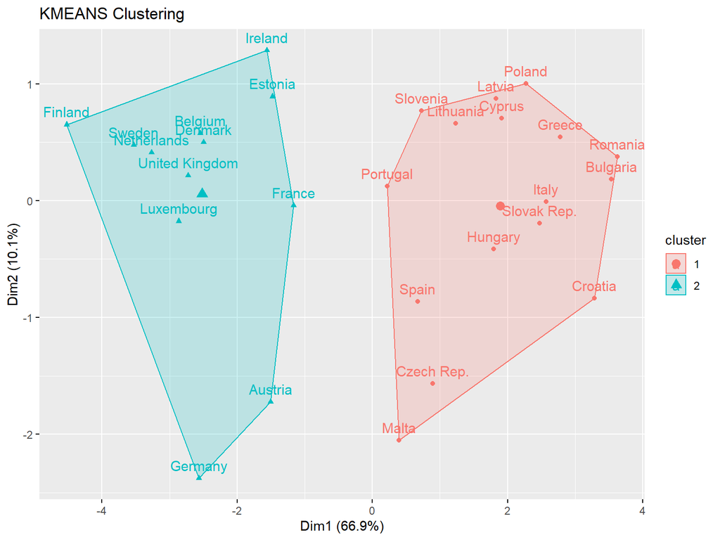

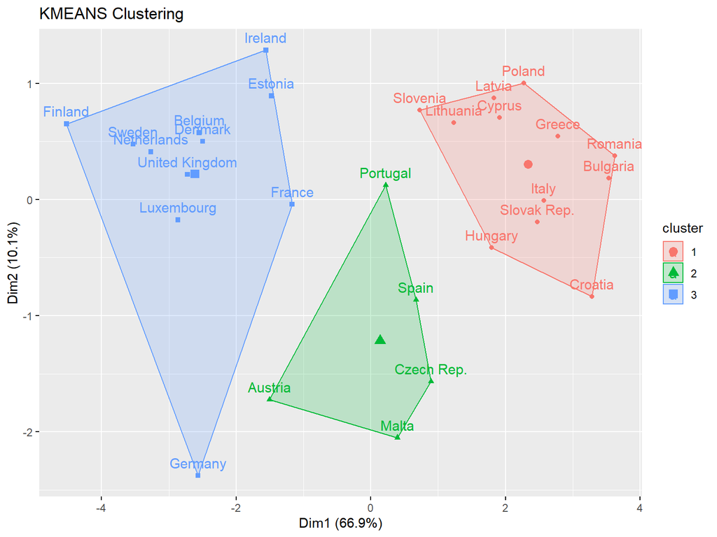

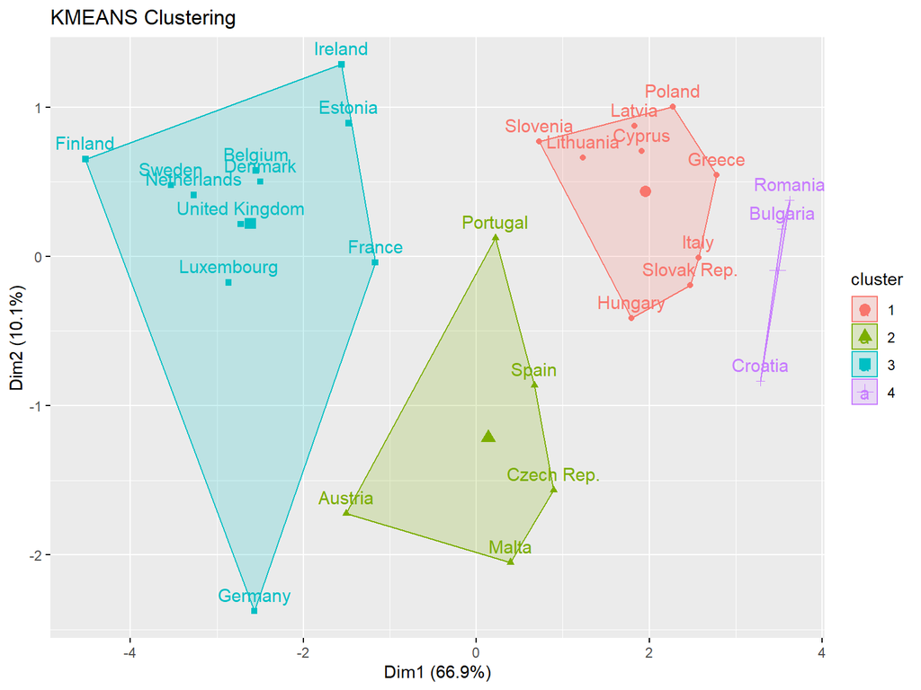

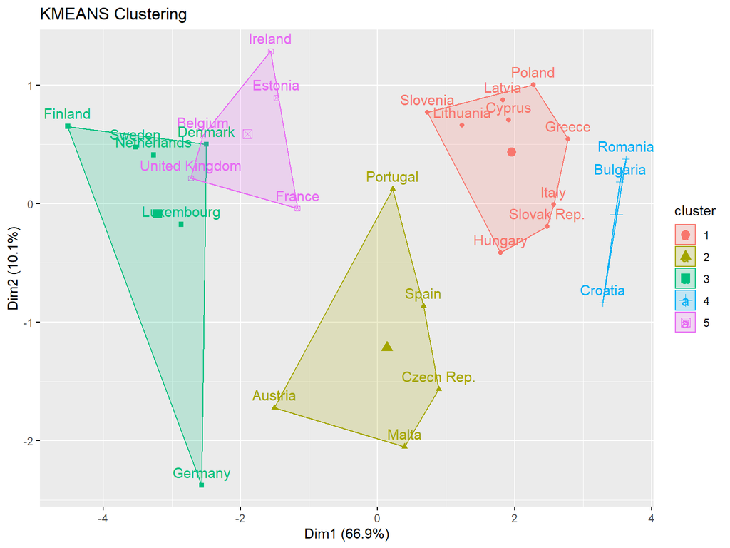

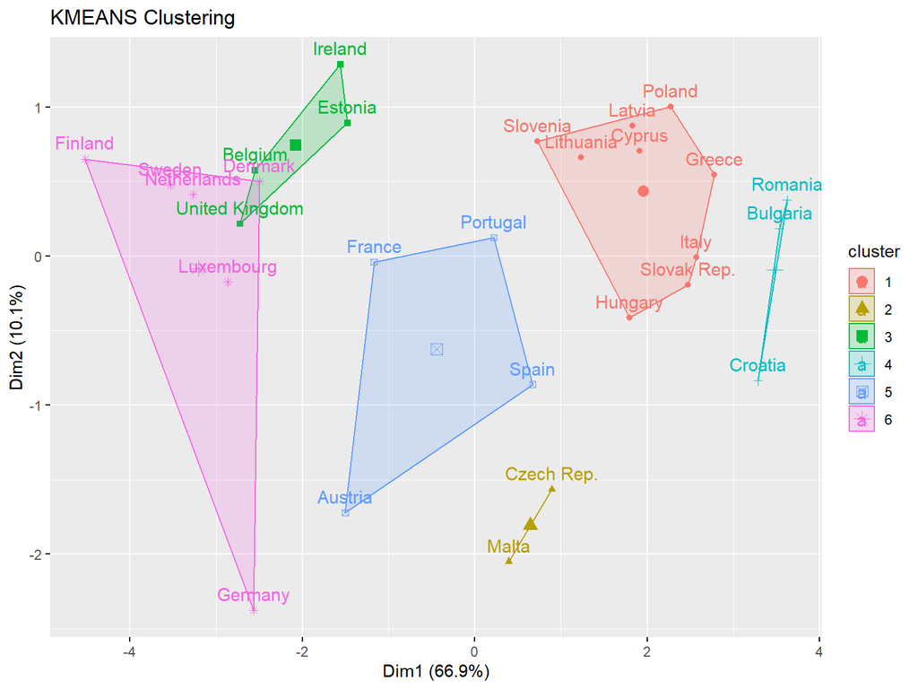

Interpretując graficznie podziały, wydaje się że optymalna liczba skupień waha się od 2 do 4. Otrzymujemy wówczas zbiory które nie nachodzą na siebie - oznacza to, że tworzące je obserwacje są bliższe innym obserwacjom z danego klastra, niż tym z pozostałych grup. Warto dodać, że charakter powstałych skupień silnie zależy od punktów startowych - z tego powodu określa się ile razy algorytm powinien zostać uruchomiony, aby uśrendić wyniki. Korzystając z wykresów wybieramy k = 4 (cztery grupy) oraz nstarts = 25 w funkcji kmeans() - w ten sposób również otrzymamy 4 klastry, natomiast procedura zostanie powtórzona 25 razy, aby uzyskać bardziej wiarygodne wyniki.

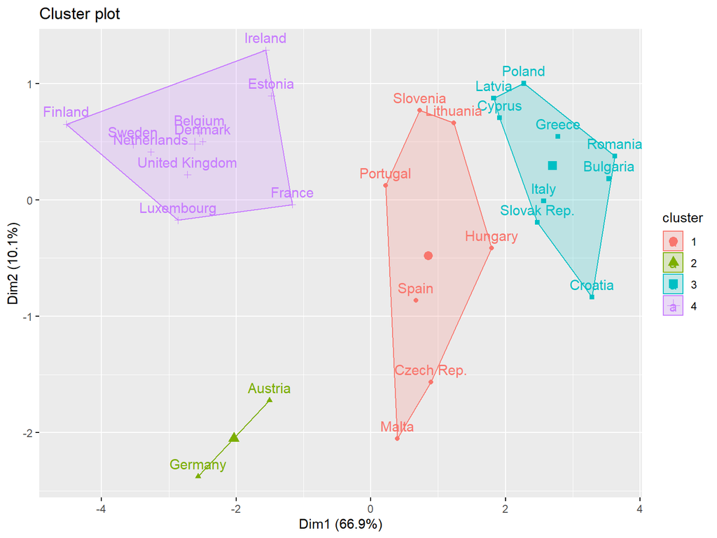

Otrzymano odmienne klastry o liczebności innej niż w przypadku funkcji eclust (która nie daje możliwości wybrania określonej liczby powtórzeń) - co potwierdza zależność wyników od tego parametru. Oceniając dopasowanie obserwacji do klastrów, przyznać należy że większa liczba powtórzeń wpłynęła na nie pozytywnie. Członkowie klastrów są zauważalnie bliżej siebie. Z tego powodu to właśnie to dopasowanie zostanie poddane interpretacji.

```
##                               I       II        III       IV
## ZaufaniePolicja       5.1327143   5.7210  4.2247778   5.9361
## ZaufaniePolitycy      2.6375714   4.6410  2.2464444   4.8466
## OWI                   4.6504286   5.8230  4.1346667   5.9789
## SysEdukacji           3.9140000   4.8005  3.3163333   4.9516
## UzytkownicyInternetu 76.2700000  86.9850 70.2227778  90.0406
## Patenty              31.1267143 196.7920 15.5020000 159.1405
## ProceduryBiznes       6.1428571   8.5000  5.5555556   3.7000
## ZmInflacji            0.4335714   0.6740 -0.6897778   0.5302
## VentureCapital        3.1897143   3.9105  2.4738889   3.9391
```

```
##                               I         II        III         IV
## ZaufaniePolicja       0.6354612  0.5374012  0.4225254  0.4050697
## ZaufaniePolitycy      0.3616540  0.6986215  0.3031044  0.7740991
## OWI                   0.3940900  0.1187939  0.4343722  0.3233404
## SysEdukacji           0.6530561  0.8082231  0.4434149  0.4937890
## UzytkownicyInternetu  3.3362476  3.7646365  8.2904587  5.1148974
## Patenty              19.6330334 31.3092741 16.0963752 89.6677515
## ProceduryBiznes       1.9518001  0.7071068  1.2360331  0.8232726
## ZmInflacji            0.4138510  0.4228499  0.6329374  0.5811400
## VentureCapital        0.1993805  0.9892424  0.5040678  0.5602619
```


### K-medoid (PAM)

W tej metodzie punktem odniesienia dla obiektów jest medoida, będąca wielowymiarową medianą. Z tego powodu jest ona bardziej odporna na zaburzenia w postaci outlierów (w przeciwieństwie do średniej, która łatwo ulega zaburzeniu). Algorytm PAM oblicza różnice pomiędzy medoidą, a najbliższymi obiektami i dąży do ich zminimalizowania (poprzez zmianę medoidy). Celem algorytmu jest znalezienie zadanej liczny obiektów, których suma różnic względem najbliższych obserwacji będzie najmniejsza. Ciekawym wyróżnikiem algorytmów opartych o szukanie medoid jest fakt, że otrzymuje się w ich rezultacie typowych przedstawicieli danej grupy. Znacznie ułatwia to przedstawienie rezultatów osobom niezaznajomionym ze statystyką, co niewątpliwie jest zaletą przy opracowywaniu np. analiz dla zarządu czy też na potrzeby ogólnodostępnych raportów.  
Podobnie jak w przypadku algorytmu k-means autor sprawdził rezultaty dla różncej liczby zadanych klastrów. Ponownie - użyta miara odległości do odległość euklidesowa.

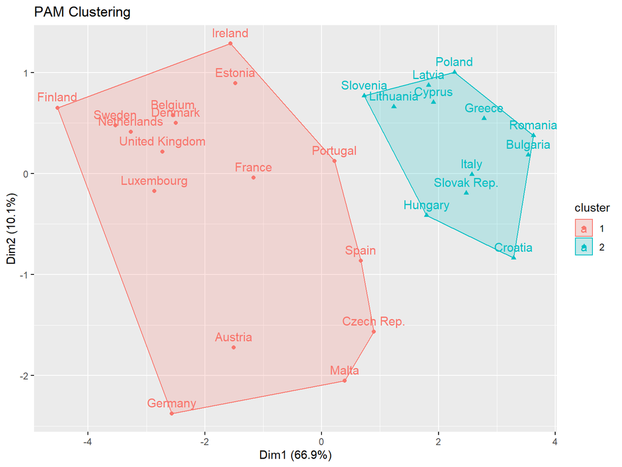

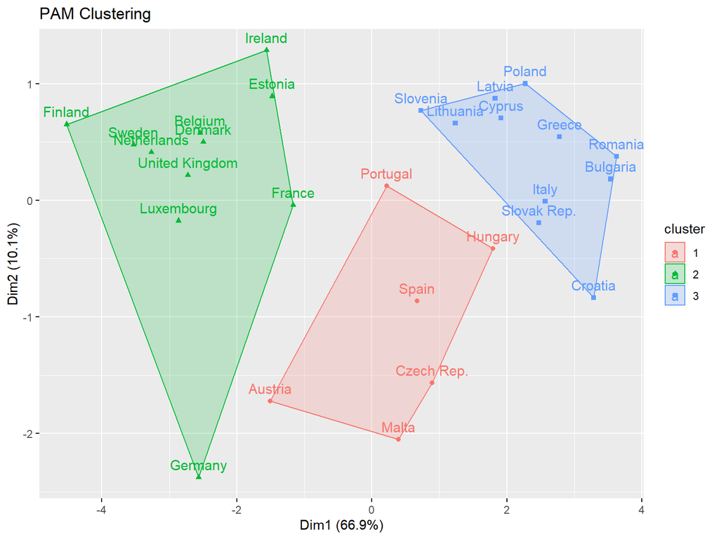

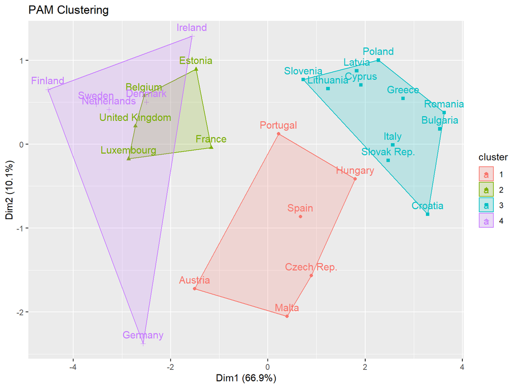

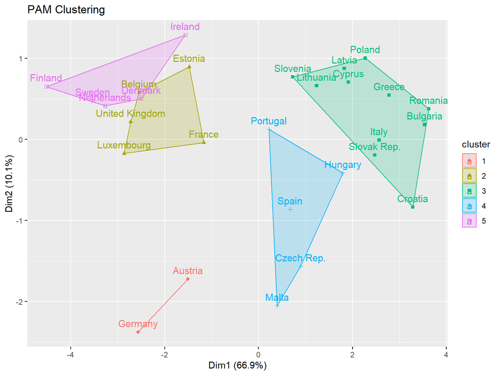

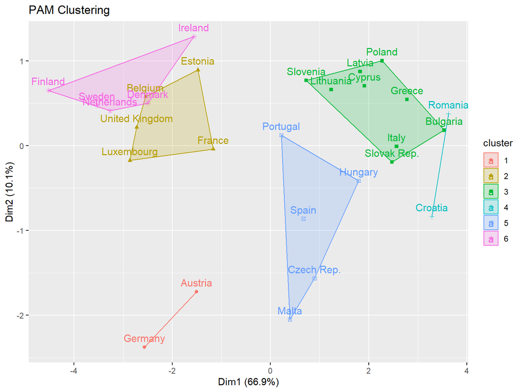

Świadczyć to może, o podobieństwie obiektów wewnątrz tych grup. Nie istnieją w nich skrajne parametry, które zaburzałyby wartości średnich.  
Analizując graficzne rezultaty, można dojść do wniosku, że 4 grupy, które wydawały się optimum dla algorytmu k-means, tutaj są najmniej sensowanym rozwiązaniem. Natomiast wydaje się, że najrozsądniej jest podzielić obserwacje na trzy grupy. Otrzymujemy wówczas 3 typowych przedstawicieli grup:

- Czechy
- Wielka Brytania
- Polska

```
##                ZaufaniePolicja ZaufaniePolitycy   OWI SysEdukacji
## Czech Rep.               -0.48            -0.66 -0.05       -0.42
## United Kingdom            0.97             1.03  1.26        0.59
## Poland                   -1.25            -0.89 -1.12       -0.62
##                UzytkownicyInternetu Patenty ProceduryBiznes ZmInflacji
## Czech Rep.                    -0.34   -0.65            1.48       0.73
## United Kingdom                 1.42    0.17           -0.67       0.67
## Poland                        -0.64   -0.81           -0.67      -0.91
##                VentureCapital
## Czech Rep.               0.19
## United Kingdom           1.33
## Poland                  -0.57
```

```
##                               I          II        III
## ZaufaniePolicja       5.3395000   5.8820000  4.3650909
## ZaufaniePolitycy      2.8845000   4.8728182  2.3200909
## OWI                   4.9150000   5.9570909  4.1983636
## SysEdukacji           3.9990000   4.9898182  3.4072727
## UzytkownicyInternetu 78.0561667  90.0048182 71.0800909
## Patenty              50.7860000 164.5760000 20.6674545
## ProceduryBiznes       7.1666667   4.1818182  5.2727273
## ZmInflacji            0.5641667   0.5160909 -0.5077273
## VentureCapital        3.2716667   4.0000909  2.5612727
```

```
##                               I         II        III
## ZaufaniePolicja       0.7639711  0.4241087  0.5051019
## ZaufaniePolitycy      0.7277254  0.7395051  0.3244135
## OWI                   0.6213360  0.3151604  0.4261538
## SysEdukacji           0.7062657  0.4852955  0.4565083
## UzytkownicyInternetu  4.6543283  4.8538687  7.6607107
## Patenty              61.1506306 86.9555424 22.2781999
## ProceduryBiznes       1.4719601  1.7786614  1.2720778
## ZmInflacji            0.4284486  0.5533002  0.7151273
## VentureCapital        0.1325710  0.5687028  0.4909988
```

Znów można podzielić UE na kraje wysoko (grupa II), średnio (grupa I) i nisko (grupa III) rozwinietę. Pomimo zastosowania median, odchylenia standardowe wewnątrz grup praktycznie nie zmieniły się - lecz może wynikać to z tego, że rozpatrywane są 3, a nie 4 grupy.

## Grupowanie hierarchiczne

Jako kolejne zostanie wykonane grupowanie hierarchiczne. Na początku należy wyznaczyć macierz odległości, a później dokonać grupowania z użyciem funkcji *hclust*. Ponownie wybrano funkcję odległości euklidesowej. Graficzne przedstawienie rezultatu grupowania to dendogram. Pokazuje on nam jak przebiegał proces łączenia obserwcji w grupy. Obserwując go możemy ustalić, które grupy powstały wcześniej (więc ich członkowie są do siebie bardziej zbliżeni). Analiza etapów formowania się grup pozwala ekspercko określić ile grup powinniśmy otrzymać. Spoglądając na dendogram możemy założyć, że będie ich ok. 5.

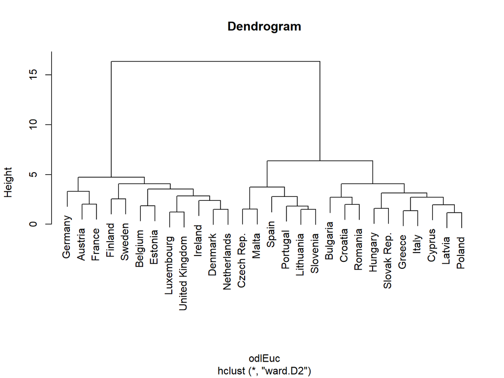

### Indeksy

Pomocne w podjęciu decyzji mogą być indeksy. Rozpatrzono następujące:

- G2 - wybrana powinna zostać liczba grup, przy której wartość indeksu jest największa
- G3 - wybrana powinna zostać liczba grup, przy której wartość indeksu jest najmniejsza
- S - wybrana powinna zostać liczba grup, przy której wartość indeksu jest największa

```
##             G2        G3         S
## [1,]        NA        NA        NA
## [2,] 0.8733724 0.4308906 0.4324443
## [3,] 0.7899345 0.4563483 0.2528660
## [4,] 0.8129684 0.4804715 0.1966653
## [5,] 0.8281470 0.5085458 0.1874009
## [6,] 0.8378782 0.5126222 0.1506206
## [7,] 0.8493789 0.4830698 0.1605833
```

Powyższe indeksy dały identyczne wyniki, więc możemy potraktować je jako wskazówki przy określeniu liczby grup. Według nich powinniśmy podzielić obserwacje na 2 skupienia. Przyglądając się dendogramowi, nie wydaje się to jednak najlepszym wyjściem. Ponadto indeks G2 wydaje się rosnąć wraz z liczbą klastrów - co również podważa jego wskazania. Pakiet NbClust zawiera więcej wskaźników - aż 30, dzięki czemu w trudnie ułatwić on może podjęcie decyzji o optymalnej liczbie grup. Ponadto zawiera on dwa wskaźniki do graficznej interpracji. Na wykresach wartości statystyki szukać należy *kolanka*, czyli znacznego wzrostu (lub spadku) wartości indeksu - wówczas z osi poziomej odczytać można sugerowaną liczbę klastrów. Podobnie w przypadku wykresu różnic wartości indeksów - tutaj poszukujemy jednak *szczytów*. Wadą tego pakietu jest, ponownie, charakter *czarnej skrzynki* - przy tak dużej liczbie statystyk trudno w pełni zrozumieć działanie każdej z nich, zatem jego rezultaty nie będą traktowane jako ostateczny wynik. Uogólniając, indeksy w tym pakiecie wskazują optymalną liczbę klastrów na podstawie:

- ich minimalnej wielkości (np. indeks McClain-Rao)
- ich maksymalnej wartości (np. indeks Silhouette)
- najmniejszej liczby grup przy której indeks przekroczył odpowiednią wartość krytyczną (np. indeks Duda-Hart)
- największej różnicy pomiędzy waartościami indeksu (np. indeks Scott’a)

```r
wyniki<-NbClust(Dane, distance = "euclidean", min.nc = 2, max.nc = 7, method = "ward.D2", index = "alllong")
```

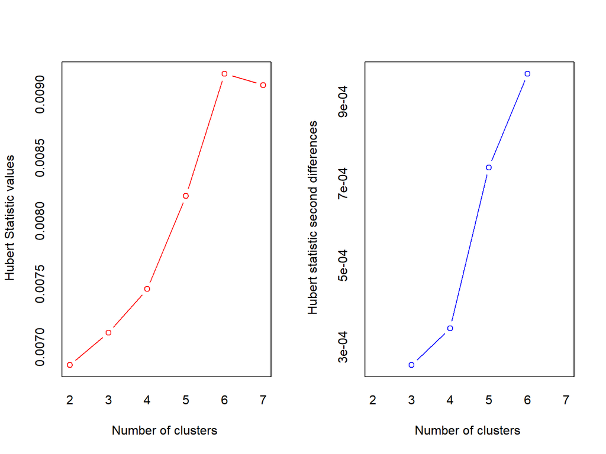

```
## *** : The Hubert index is a graphical method of determining the number of clusters.
##                 In the plot of Hubert index, we seek a significant knee that corresponds to a
##                 significant increase of the value of the measure i.e the significant peak in Hubert
##                 index second differences plot.
##
```

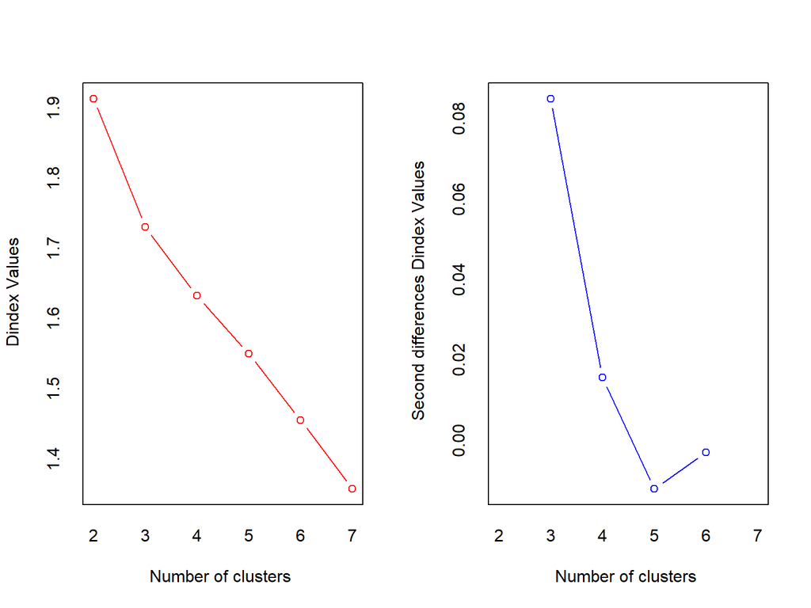

```
## *** : The D index is a graphical method of determining the number of clusters.
##                 In the plot of D index, we seek a significant knee (the significant peak in Dindex
##                 second differences plot) that corresponds to a significant increase of the value of
##                 the measure.
##
## * Among all indices:
## * 17 proposed 2 as the best number of clusters
## * 4 proposed 3 as the best number of clusters
## * 1 proposed 4 as the best number of clusters
## * 1 proposed 5 as the best number of clusters
## * 4 proposed 7 as the best number of clusters
##
##                    ***** Conclusion *****
##
## * According to the majority rule, the best number of clusters is  2
##
##
```

```
##                                I         II
## ZaufaniePolicja        5.9002500  4.6220000
## ZaufaniePolitycy       4.8123333  2.4175625
## OWI                    5.9529167  4.3603125
## SysEdukacji            4.9264167  3.5778125
## UzytkownicyInternetu  89.5313333 72.8684375
## Patenty              165.4157500 22.3378125
## ProceduryBiznes        4.5000000  5.8125000
## ZmInflacji             0.5541667 -0.1983125
## VentureCapital         3.9343333  2.7870625
```

```
##                               I         II
## ZaufaniePolicja       0.4092839  0.6878449
## ZaufaniePolitycy      0.7355634  0.3761294
## OWI                   0.3008414  0.4822649
## SysEdukacji           0.5121900  0.6076361
## UzytkownicyInternetu  4.9100381  7.1209876
## Patenty              82.9598739 18.8798851
## ProceduryBiznes       2.0225996  1.5585784
## ZmInflacji            0.5437897  0.7832112
## VentureCapital        0.5881407  0.5347142
```

## Grupowanie hierarchiczne - opis i profilowanie klas

```
##                                I      II        III
## ZaufaniePolicja        5.9002500  4.2503  5.2415000
## ZaufaniePolitycy       4.8123333  2.2442  2.7065000
## OWI                    5.9529167  4.1240  4.7541667
## SysEdukacji            4.9264167  3.2757  4.0813333
## UzytkownicyInternetu  89.5313333 71.1264 75.7718333
## Patenty              165.4157500 16.4239 32.1943333
## ProceduryBiznes        4.5000000  5.6000  6.1666667
## ZmInflacji             0.5541667 -0.5824  0.4418333
## VentureCapital         3.9343333  2.5554  3.1731667
```

```
##                               I         II        III
## ZaufaniePolicja       0.4092839  0.4064543  0.6206164
## ZaufaniePolitycy      0.7355634  0.2858577  0.3421150
## OWI                   0.3008414  0.4109169  0.3097918
## SysEdukacji           0.5121900  0.4373570  0.5259040
## UzytkownicyInternetu  4.9100381  8.3222702  3.3573844
## Patenty              82.9598739 15.4532892 21.2831575
## ProceduryBiznes       2.0225996  1.1737878  2.1369761
## ZmInflacji            0.5437897  0.6865838  0.4527182
## VentureCapital        0.5881407  0.5406416  0.2130797
```

# Podsumowanie

Choć każda z rozpatrywanych metod dała różne rezultaty (co można zauważyć porównując statystyki opisowe), to jednak zauważyć można kilka podobieństw:

- Algorytmy dzieliły Unię Europejską na kraje wyraźnie lepsze i gorsze
- Każda z klas znacząco różniła się od pozostałych, najczęściej pod względem wszystkich zmiennych
- Klasy nie były jednorodne pod względem wszystkich wymiarów - wartości odchyleń standardowych wahały się w zależności od konkretnej zmiennej